# **Deep Learning Project: Street View Housing Number Digit Recognition**

# **Marks: 60**

## **Context**

One of the most interesting tasks in deep learning is to recognize objects in natural scenes. The ability to process visual information using machine learning algorithms can be very useful as demonstrated in various applications.

The SVHN dataset contains over 600,000 labeled digits cropped from street-level photos. It is one of the most popular image recognition datasets. It has been used in neural networks created by Google to improve the map quality by automatically transcribing the address numbers from a patch of pixels. The transcribed number with a known street address helps pinpoint the location of the building it represents.

## **Objective**

Our objective is to predict the number depicted inside the image by using Artificial or Fully Connected Feed Forward Neural Networks and Convolutional Neural Networks. We will go through various models of each and finally select the one that is giving us the best performance.

## **Dataset**

Here, we will use a subset of the original data to save some computation time. The dataset is provided as a .h5 file. The basic preprocessing steps have been applied on the dataset.

## **Mount the drive**

Let us start by mounting the Google drive. You can run the below cell to mount the Google drive.

```python
# Importing Drive

from google.colab import drive
drive.mount('/content/drive')
```

## **Importing the necessary libraries**

```python
import numpy as np
import pandas as pd
import matplotlib.pyplot as plt
import seaborn as sns

import sklearn
from sklearn.metrics import classification_report, confusion_matrix

import tensorflow as tf
from tensorflow import keras

from keras.models import Sequential
from keras.layers import Input, Dense, Conv2D, MaxPool2D, Flatten, Dropout, BatchNormalization, LeakyReLU, MaxPool2D
from keras.optimizers import Adam
from keras.utils import to_categorical

import h5py

import random
```

**Let us check the version of tensorflow.**

```python
!pip install --upgrade tensorflow
```

```python
tf.__version__
```

```
'2.18.0'
```

## **Load the dataset**

- Let us now load the dataset that is available as a .h5 file.
- Split the data into the train and the test dataset.

```python
# Load the data

data_file = h5py.File('/content/drive/MyDrive/Digit Recognition Elective Project/SVHN_single_grey1.h5')
```

```python
# Split the data

x_train = data_file['X_train'][:]
y_train = data_file['y_train'][:]
x_test = data_file['X_test'][:]
y_test = data_file['y_test'][:]

data_file.close()
```

Check the number of images in the training and the testing dataset.

```python
print(f'Train data lenght = {len(x_train)}')
print(f'Test data length = {len(x_test)}')
```

```
Train data lenght = 42000
Test data length = 18000
```

## **Visualizing images**

- Use X_train to visualize the first 10 images.
- Use Y_train to print the first 10 labels.

```python
# Visualizing the first 10 images and their labels

for i in range(10):
  plt.figure(figsize=(10, 1))
  plt.imshow(x_train[i], cmap='gray')
  plt.title(f"Label: {y_train[i]}")
  plt.axis('off')
```

[output not shown]

## **Data preparation**

- Print the shape and the array of pixels for the first image in the training dataset.
- Normalize the train and the test dataset by dividing by 255.
- Print the new shapes of the train and the test dataset.
- One-hot encode the target variable.

```python
# Print the shape and the array of pixels for the first image in the training dataset.

print("Shape of the first image:", x_train[0].shape)
print("Pixel array of the first image:\n", x_train[1])
```

```
Shape of the first image: (32, 32)
Pixel array of the first image:
 [[86.9591 87.0685 88.3735 ... 91.8014 89.7477 92.5302]
 [86.688  86.9114 87.4337 ... 90.7306 87.204  88.5629]
 [85.9654 85.8145 85.9239 ... 63.8626 59.8199 54.8805]
 ...
 [90.2236 91.0448 93.4637 ... 55.3535 48.5822 44.0557]
 [90.6427 90.4039 90.937  ... 78.2696 77.4977 74.27  ]
 [88.0236 88.1977 86.6709 ... 75.2206 76.6396 79.2865]]
```

### **Normalize the train and the test data**

```python
# Normilizing pixels information to be between 0 and 1 values

x_train = x_train/255
x_test = x_test/255

print("Normilized pixel array of the first image:\n", x_train[1])
```

```
Normilized pixel array of the first image:
 [[0.34101608 0.3414451  0.34656274 ... 0.3600055  0.35195178 0.3628635 ]
 [0.33995295 0.340829   0.34287727 ... 0.35580626 0.3419765  0.34730548]
 [0.33711922 0.33652744 0.33695647 ... 0.25044155 0.23458785 0.21521765]
 ...
 [0.35381806 0.35703844 0.3665243  ... 0.21707255 0.19051842 0.17276745]
 [0.35546157 0.3545251  0.35661566 ... 0.3069396  0.30391255 0.29125488]
 [0.34519058 0.34587333 0.3398859  ... 0.29498273 0.30054745 0.31092745]]
```

Print the shapes of Training and Test data

```python
# Flatten the matrixes into vectors

x_train = x_train.reshape(x_train.shape[0], 1024)
x_test = x_test.reshape(x_test.shape[0], 1024)
```

```python
# Shape after flatten

print(f'Train data shape = {x_train.shape}')
print(f'Test data shape = {x_test.shape}')
```

```
Train data shape = (42000, 1024)
Test data shape = (18000, 1024)
```

## **Model Building**

Now that we have done the data preprocessing, let's build an ANN model.

### Fix the seed for random number generators

```python
np.random.seed(42)

random.seed(42)

tf.random.set_seed(42)
```

### **Model Architecture**

- Write a function that returns a sequential model with the following architecture:
- First hidden layer with **64 nodes and the relu activation** and the **input shape = (1024, )**
- Second hidden layer with **32 nodes and the relu activation**
- Output layer with **activation as 'softmax' and number of nodes equal to the number of classes, i.e., 10**
- Compile the model with the **loss equal to categorical_crossentropy, optimizer equal to Adam(learning_rate = 0.001), and metric equal to 'accuracy'**. Do not fit the model here, just return the compiled model.
- Call the nn_model_1 function and store the model in a new variable.
- Print the summary of the model.
- Fit on the train data with a **validation split of 0.2, batch size = 128, verbose = 1, and epochs = 20**. Store the model building history to use later for visualization.

### **Build and train an ANN model as per the above mentioned architecture.**

```python
def nn_model_1():

  # Initialize the sequentila model

  model = Sequential()

  # Adding respective layers with activation function and number of neurons per layer

  model.add(Dense(units = 64, activation = 'relu', input_shape = (1024,)))
  model.add(Dense(units = 32, activation = 'relu'))

  # Output layer

  model.add(Dense(units = 10, activation = 'softmax'))

  # Compile

  model.compile(loss='categorical_crossentropy', optimizer=Adam(learning_rate=0.001), metrics=['accuracy'])

  return model
```

### **Plot the Training and Validation Accuracies and write down your Observations.**

```python
model_1 = nn_model_1()
model_1.summary()
```

```
Model: "sequential_1"
```

```
┏━━━━━━━━━━━━━━━━━━━━━━━━━━━━━━━━━━━━━━┳━━━━━━━━━━━━━━━━━━━━━━━━━━━━━┳━━━━━━━━━━━━━━━━━┓
┃ Layer (type)                         ┃ Output Shape                ┃         Param # ┃
┡━━━━━━━━━━━━━━━━━━━━━━━━━━━━━━━━━━━━━━╇━━━━━━━━━━━━━━━━━━━━━━━━━━━━━╇━━━━━━━━━━━━━━━━━┩
│ dense_4 (Dense)                      │ (None, 64)                  │          65,600 │
├──────────────────────────────────────┼─────────────────────────────┼─────────────────┤
│ dense_5 (Dense)                      │ (None, 32)                  │           2,080 │
├──────────────────────────────────────┼─────────────────────────────┼─────────────────┤
│ dense_6 (Dense)                      │ (None, 10)                  │             330 │
└──────────────────────────────────────┴─────────────────────────────┴─────────────────┘
```

```
 Total params: 68,010 (265.66 KB)
```

```
 Trainable params: 68,010 (265.66 KB)
```

```
 Non-trainable params: 0 (0.00 B)
```

```python
# Fittin the model

history = model_1.fit(x_train, to_categorical(y_train, num_classes=10), validation_split=0.2, batch_size=128, verbose=1, epochs=20)
```

```
263/263 ━━━━━━━━━━━━━━━━━━━━ 6s 12ms/step - accuracy: 0.1073 - loss: 2.3092 - val_accuracy: 0.1632 - val_loss: 2.2677
263/263 ━━━━━━━━━━━━━━━━━━━━ 2s 4ms/step - accuracy: 0.1778 - loss: 2.2184 - val_accuracy: 0.2912 - val_loss: 2.0361
263/263 ━━━━━━━━━━━━━━━━━━━━ 1s 5ms/step - accuracy: 0.3392 - loss: 1.9184 - val_accuracy: 0.4385 - val_loss: 1.6545
263/263 ━━━━━━━━━━━━━━━━━━━━ 1s 4ms/step - accuracy: 0.4624 - loss: 1.6101 - val_accuracy: 0.5181 - val_loss: 1.4750
263/263 ━━━━━━━━━━━━━━━━━━━━ 1s 5ms/step - accuracy: 0.5249 - loss: 1.4636 - val_accuracy: 0.5407 - val_loss: 1.4091
263/263 ━━━━━━━━━━━━━━━━━━━━ 2s 7ms/step - accuracy: 0.5543 - loss: 1.3851 - val_accuracy: 0.5619 - val_loss: 1.3614
263/263 ━━━━━━━━━━━━━━━━━━━━ 2s 7ms/step - accuracy: 0.5760 - loss: 1.3307 - val_accuracy: 0.5850 - val_loss: 1.3071
263/263 ━━━━━━━━━━━━━━━━━━━━ 2s 4ms/step - accuracy: 0.5938 - loss: 1.2857 - val_accuracy: 0.6011 - val_loss: 1.2657
263/263 ━━━━━━━━━━━━━━━━━━━━ 1s 4ms/step - accuracy: 0.6092 - loss: 1.2481 - val_accuracy: 0.6158 - val_loss: 1.2321
263/263 ━━━━━━━━━━━━━━━━━━━━ 1s 4ms/step - accuracy: 0.6184 - loss: 1.2200 - val_accuracy: 0.6267 - val_loss: 1.2032
263/263 ━━━━━━━━━━━━━━━━━━━━ 1s 2ms/step - accuracy: 0.6264 - loss: 1.1969 - val_accuracy: 0.6314 - val_loss: 1.1833
263/263 ━━━━━━━━━━━━━━━━━━━━ 1s 2ms/step - accuracy: 0.6312 - loss: 1.1791 - val_accuracy: 0.6349 - val_loss: 1.1729
263/263 ━━━━━━━━━━━━━━━━━━━━ 1s 2ms/step - accuracy: 0.6366 - loss: 1.1648 - val_accuracy: 0.6386 - val_loss: 1.1586
263/263 ━━━━━━━━━━━━━━━━━━━━ 1s 2ms/step - accuracy: 0.6406 - loss: 1.1522 - val_accuracy: 0.6440 - val_loss: 1.1452
263/263 ━━━━━━━━━━━━━━━━━━━━ 1s 2ms/step - accuracy: 0.6447 - loss: 1.1401 - val_accuracy: 0.6462 - val_loss: 1.1351
263/263 ━━━━━━━━━━━━━━━━━━━━ 1s 2ms/step - accuracy: 0.6489 - loss: 1.1292 - val_accuracy: 0.6494 - val_loss: 1.1262
263/263 ━━━━━━━━━━━━━━━━━━━━ 1s 2ms/step - accuracy: 0.6525 - loss: 1.1191 - val_accuracy: 0.6545 - val_loss: 1.1163
263/263 ━━━━━━━━━━━━━━━━━━━━ 1s 2ms/step - accuracy: 0.6557 - loss: 1.1102 - val_accuracy: 0.6554 - val_loss: 1.1068
263/263 ━━━━━━━━━━━━━━━━━━━━ 1s 3ms/step - accuracy: 0.6592 - loss: 1.1017 - val_accuracy: 0.6588 - val_loss: 1.1022
263/263 ━━━━━━━━━━━━━━━━━━━━ 1s 3ms/step - accuracy: 0.6613 - loss: 1.0945 - val_accuracy: 0.6617 - val_loss: 1.0962
```

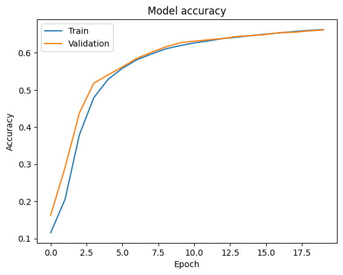

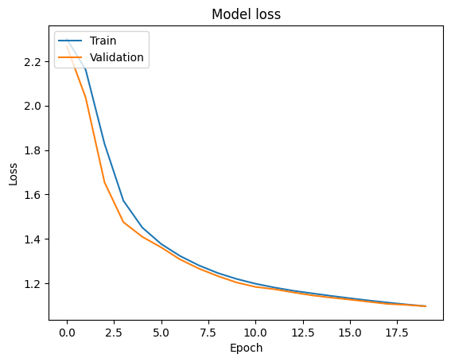

```python
# Plot the training and validation accuracy

plt.plot(history.history['accuracy'])
plt.plot(history.history['val_accuracy'])
plt.title('Model accuracy')
plt.ylabel('Accuracy')
plt.xlabel('Epoch')
plt.legend(['Train', 'Validation'], loc='upper left')
plt.show()

# Plot the training and validation loss

plt.plot(history.history['loss'])
plt.plot(history.history['val_loss'])
plt.title('Model loss')
plt.ylabel('Loss')
plt.xlabel('Epoch')
plt.legend(['Train', 'Validation'], loc='upper left')
plt.show()
```

**Observations:**

- Training accuracy and validation accuraccy seems to be improving over the epochs, indicating the model is actually fitting well over training and test data.
- Doesn't seems like the model is overfitting, becuase it is not doing better on training than validation.

The model shows a good learning and generalization, but is still not getting a good accuracy to rely on a consistent prediction not going over .7 on accuracy

A more complex model would help to improve the accuracy that is actually not too high with this one.

Let's build one more model with higher complexity and see if we can improve the performance of the model.

First, we need to clear the previous model's history from the Keras backend. Also, let's fix the seed again after clearing the backend.

```python
# Clear Keras backend

keras.backend.clear_session()

# Fix the seed for random number generators

np.random.seed(42)

random.seed(42)

tf.random.set_seed(42)
```

### **Second Model Architecture**

- Write a function that returns a sequential model with the following architecture:
- First hidden layer with **256 nodes and the relu activation** and the **input shape = (1024, )**
- Second hidden layer with **128 nodes and the relu activation**
- Add the **Dropout layer with the rate equal to 0.2**
- Third hidden layer with **64 nodes and the relu activation**
- Fourth hidden layer with **64 nodes and the relu activation**
- Fifth hidden layer with **32 nodes and the relu activation**
- Add the **BatchNormalization layer**
- Output layer with **activation as 'softmax' and number of nodes equal to the number of classes, i.e., 10** -Compile the model with the **loss equal to categorical_crossentropy, optimizer equal to Adam(learning_rate = 0.0005), and metric equal to 'accuracy'**. Do not fit the model here, just return the compiled model.
- Call the nn_model_2 function and store the model in a new variable.
- Print the summary of the model.
- Fit on the train data with a **validation split of 0.2, batch size = 128, verbose = 1, and epochs = 30**. Store the model building history to use later for visualization.

### **Build and train the new ANN model as per the above mentioned architecture**

```python
def nn_model_2():

  # Initialize the sequential model

  model = Sequential()

  # Adding respective layers

  model.add(Input(shape=(1024,)))
  model.add(Dense(units = 256, activation = 'relu'))
  model.add(Dense(units = 128, activation = 'relu'))
  model.add(Dropout(0.2))
  model.add(Dense(units = 64, activation = 'relu'))
  model.add(Dense(units = 64, activation = 'relu'))
  model.add(Dense(units = 32, activation = 'relu'))
  model.add(BatchNormalization())

  # Output layer

  model.add(Dense(10, activation = 'softmax'))

  # Compile

  model.compile(loss='categorical_crossentropy', optimizer=Adam(learning_rate=0.0005), metrics=['accuracy'])

  return model
```

### **Plot the Training and Validation Accuracies and write down your Observations.**

```python
model_2 = nn_model_2()
model_2.summary()
```

```
Model: "sequential"
```

```
┏━━━━━━━━━━━━━━━━━━━━━━━━━━━━━━━━━━━━━━┳━━━━━━━━━━━━━━━━━━━━━━━━━━━━━┳━━━━━━━━━━━━━━━━━┓
┃ Layer (type)                         ┃ Output Shape                ┃         Param # ┃
┡━━━━━━━━━━━━━━━━━━━━━━━━━━━━━━━━━━━━━━╇━━━━━━━━━━━━━━━━━━━━━━━━━━━━━╇━━━━━━━━━━━━━━━━━┩
│ dense (Dense)                        │ (None, 256)                 │         262,400 │
├──────────────────────────────────────┼─────────────────────────────┼─────────────────┤
│ dense_1 (Dense)                      │ (None, 128)                 │          32,896 │
├──────────────────────────────────────┼─────────────────────────────┼─────────────────┤
│ dropout (Dropout)                    │ (None, 128)                 │               0 │
├──────────────────────────────────────┼─────────────────────────────┼─────────────────┤
│ dense_2 (Dense)                      │ (None, 64)                  │           8,256 │
├──────────────────────────────────────┼─────────────────────────────┼─────────────────┤
│ dense_3 (Dense)                      │ (None, 64)                  │           4,160 │
├──────────────────────────────────────┼─────────────────────────────┼─────────────────┤
│ dense_4 (Dense)                      │ (None, 32)                  │           2,080 │
├──────────────────────────────────────┼─────────────────────────────┼─────────────────┤
│ batch_normalization                  │ (None, 32)                  │             128 │
│ (BatchNormalization)                 │                             │                 │
├──────────────────────────────────────┼─────────────────────────────┼─────────────────┤
│ dense_5 (Dense)                      │ (None, 10)                  │             330 │
└──────────────────────────────────────┴─────────────────────────────┴─────────────────┘
```

```
 Total params: 310,250 (1.18 MB)
```

```
 Trainable params: 310,186 (1.18 MB)
```

```
 Non-trainable params: 64 (256.00 B)
```

```python
history_2 = model_2.fit(x_train, to_categorical(y_train, num_classes=10), validation_split=0.2, batch_size=128, verbose=1, epochs=30)
```

```
263/263 ━━━━━━━━━━━━━━━━━━━━ 5s 10ms/step - accuracy: 0.0988 - loss: 2.4460 - val_accuracy: 0.1011 - val_loss: 2.3135
263/263 ━━━━━━━━━━━━━━━━━━━━ 2s 3ms/step - accuracy: 0.1260 - loss: 2.2858 - val_accuracy: 0.2324 - val_loss: 2.1053
263/263 ━━━━━━━━━━━━━━━━━━━━ 1s 3ms/step - accuracy: 0.3413 - loss: 1.8532 - val_accuracy: 0.4651 - val_loss: 1.5719
263/263 ━━━━━━━━━━━━━━━━━━━━ 1s 3ms/step - accuracy: 0.4923 - loss: 1.4888 - val_accuracy: 0.5430 - val_loss: 1.3570
263/263 ━━━━━━━━━━━━━━━━━━━━ 1s 3ms/step - accuracy: 0.5515 - loss: 1.3334 - val_accuracy: 0.6214 - val_loss: 1.1853
263/263 ━━━━━━━━━━━━━━━━━━━━ 1s 4ms/step - accuracy: 0.6044 - loss: 1.2082 - val_accuracy: 0.6532 - val_loss: 1.0916
263/263 ━━━━━━━━━━━━━━━━━━━━ 1s 4ms/step - accuracy: 0.6390 - loss: 1.1209 - val_accuracy: 0.6757 - val_loss: 1.0286
263/263 ━━━━━━━━━━━━━━━━━━━━ 1s 3ms/step - accuracy: 0.6568 - loss: 1.0666 - val_accuracy: 0.6775 - val_loss: 1.0158
263/263 ━━━━━━━━━━━━━━━━━━━━ 1s 3ms/step - accuracy: 0.6682 - loss: 1.0333 - val_accuracy: 0.6701 - val_loss: 1.0078
263/263 ━━━━━━━━━━━━━━━━━━━━ 1s 3ms/step - accuracy: 0.6849 - loss: 0.9927 - val_accuracy: 0.7050 - val_loss: 0.9263
263/263 ━━━━━━━━━━━━━━━━━━━━ 1s 3ms/step - accuracy: 0.6956 - loss: 0.9590 - val_accuracy: 0.6912 - val_loss: 0.9802
263/263 ━━━━━━━━━━━━━━━━━━━━ 1s 3ms/step - accuracy: 0.7021 - loss: 0.9348 - val_accuracy: 0.7095 - val_loss: 0.9124
263/263 ━━━━━━━━━━━━━━━━━━━━ 1s 3ms/step - accuracy: 0.7102 - loss: 0.9072 - val_accuracy: 0.7276 - val_loss: 0.8686
263/263 ━━━━━━━━━━━━━━━━━━━━ 1s 3ms/step - accuracy: 0.7190 - loss: 0.8801 - val_accuracy: 0.7320 - val_loss: 0.8480
263/263 ━━━━━━━━━━━━━━━━━━━━ 1s 3ms/step - accuracy: 0.7302 - loss: 0.8622 - val_accuracy: 0.7281 - val_loss: 0.8657
263/263 ━━━━━━━━━━━━━━━━━━━━ 1s 3ms/step - accuracy: 0.7306 - loss: 0.8527 - val_accuracy: 0.7269 - val_loss: 0.8666
263/263 ━━━━━━━━━━━━━━━━━━━━ 1s 3ms/step - accuracy: 0.7407 - loss: 0.8254 - val_accuracy: 0.7275 - val_loss: 0.8530
263/263 ━━━━━━━━━━━━━━━━━━━━ 1s 4ms/step - accuracy: 0.7391 - loss: 0.8210 - val_accuracy: 0.7213 - val_loss: 0.8838
263/263 ━━━━━━━━━━━━━━━━━━━━ 1s 4ms/step - accuracy: 0.7410 - loss: 0.8098 - val_accuracy: 0.7469 - val_loss: 0.8107
263/263 ━━━━━━━━━━━━━━━━━━━━ 1s 3ms/step - accuracy: 0.7455 - loss: 0.7989 - val_accuracy: 0.7343 - val_loss: 0.8379
263/263 ━━━━━━━━━━━━━━━━━━━━ 1s 3ms/step - accuracy: 0.7503 - loss: 0.7828 - val_accuracy: 0.7498 - val_loss: 0.7976
263/263 ━━━━━━━━━━━━━━━━━━━━ 1s 3ms/step - accuracy: 0.7602 - loss: 0.7688 - val_accuracy: 0.7268 - val_loss: 0.8618
263/263 ━━━━━━━━━━━━━━━━━━━━ 1s 3ms/step - accuracy: 0.7548 - loss: 0.7703 - val_accuracy: 0.7425 - val_loss: 0.8113
263/263 ━━━━━━━━━━━━━━━━━━━━ 1s 3ms/step - accuracy: 0.7596 - loss: 0.7494 - val_accuracy: 0.7579 - val_loss: 0.7776
263/263 ━━━━━━━━━━━━━━━━━━━━ 1s 3ms/step - accuracy: 0.7596 - loss: 0.7503 - val_accuracy: 0.7546 - val_loss: 0.7795
263/263 ━━━━━━━━━━━━━━━━━━━━ 1s 3ms/step - accuracy: 0.7626 - loss: 0.7421 - val_accuracy: 0.7515 - val_loss: 0.7818
263/263 ━━━━━━━━━━━━━━━━━━━━ 1s 3ms/step - accuracy: 0.7721 - loss: 0.7192 - val_accuracy: 0.7462 - val_loss: 0.8002
263/263 ━━━━━━━━━━━━━━━━━━━━ 1s 3ms/step - accuracy: 0.7700 - loss: 0.7227 - val_accuracy: 0.7663 - val_loss: 0.7501
263/263 ━━━━━━━━━━━━━━━━━━━━ 1s 3ms/step - accuracy: 0.7731 - loss: 0.7095 - val_accuracy: 0.7595 - val_loss: 0.7532
263/263 ━━━━━━━━━━━━━━━━━━━━ 2s 4ms/step - accuracy: 0.7707 - loss: 0.7161 - val_accuracy: 0.7611 - val_loss: 0.7611
```

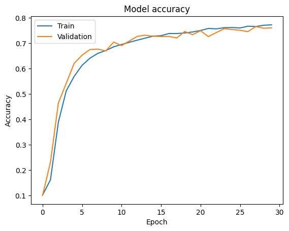

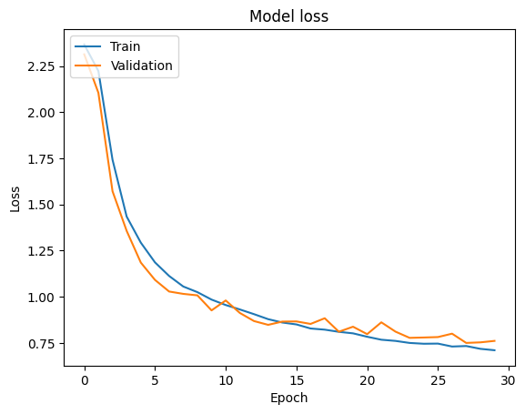

```python
# Plot the training and validation accuracy

plt.plot(history_2.history['accuracy'])
plt.plot(history_2.history['val_accuracy'])
plt.title('Model accuracy')
plt.ylabel('Accuracy')
plt.xlabel('Epoch')
plt.legend(['Train', 'Validation'], loc='upper left')
plt.show()

# Plot the training and validation loss

plt.plot(history_2.history['loss'])
plt.plot(history_2.history['val_loss'])
plt.title('Model loss')
plt.ylabel('Loss')
plt.xlabel('Epoch')
plt.legend(['Train', 'Validation'], loc='upper left')
plt.show()
```

**Observations:**

- As we saw on model 1 acuraccy is improving over epoch on training and validation data, but is significantly better than the first model.
- There is noise on the validation data and this could mean that the model is overfitting a bit on the training data and the moment he needs to validates the results the model is not being consistent with it.
- The addition of regularization (Dropout and Batch Normalization) helped improving the accuracy of the model.

Even with the accuracy improve, it seems to not be good enough. I think convulutional neural networks are really needed, since it is an image recognition model that relies on the filters and pooling to extract more information from the data.

## **Predictions on the test data**

- Make predictions on the test set using the second model.
- Print the obtained results using the classification report and the confusion matrix.
- Final observations on the obtained results.

```python
test_pred = model_2.predict(x_test)
test_pred_1 = np.argmax(test_pred, axis=1)
```

```
563/563 ━━━━━━━━━━━━━━━━━━━━ 2s 2ms/step
```

```python
print(test_pred_1) # checking prediction shape and format
```

```
[0 2 2 ... 7 9 2]
```

**Note:** Earlier, we noticed that each entry of the target variable is a one-hot encoded vector but to print the classification report and confusion matrix, we must convert each entry of y_test to a single label.

```python
print(y_test) # the y_test is okay. The prediction is already decoded, so we don't need to encode the y_test
```

```
[1 7 2 ... 7 9 2]
```

I didn't encode the y_test, neither x_test, I've used the to_categorical function directly on the model fit.

### **Print the classification report and the confusion matrix for the test predictions. Write your observations on the final results.**

```
              precision    recall  f1-score   support

           0       0.75      0.82      0.78      1814
           1       0.76      0.81      0.79      1828
           2       0.81      0.77      0.79      1803
           3       0.64      0.76      0.69      1719
           4       0.88      0.78      0.82      1812
           5       0.70      0.77      0.73      1768
           6       0.80      0.72      0.76      1832
           7       0.86      0.73      0.79      1808
           8       0.70      0.74      0.72      1812
           9       0.80      0.72      0.76      1804

    accuracy                           0.76     18000
   macro avg       0.77      0.76      0.76     18000
weighted avg       0.77      0.76      0.76     18000
```

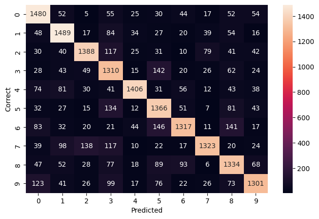

```python
print(classification_report(y_test, test_pred_1))

# Plotting the heatmap using confusion matrix

cm = confusion_matrix(y_test, test_pred_1)
plt.figure(figsize = (8, 5))

sns.heatmap(cm, annot = True,  fmt = '.0f')

plt.ylabel('Correct')

plt.xlabel('Predicted')

plt.show()
```

**Final Observations:**

- The confusion matrix shows that the model is able to correctly classify most of the digits, but there are still several misclassifications.
- The classification report indicates that the model has a good precision, recall, and F1-score for most of the classes.
- Overall, the second ANN model shows a good balance between learning and generalization, but further improvements can be made by exploring more complex architectures or using convolutional neural networks (CNNs).

Convolutional Neural Network is since the start of the investigation the way to get a good result since is much more effective extracting information from non flatten data.

## **Using Convolutional Neural Networks**

### **Load the dataset again and split the data into the train and the test dataset.**

```python
# Load the data
data_file = h5py.File('/content/drive/MyDrive/Digit Recognition Elective Project/SVHN_single_grey1.h5')

# Split the data
x_train = data_file['X_train'][:]
y_train = data_file['y_train'][:]
x_test = data_file['X_test'][:]
y_test = data_file['y_test'][:]

# Close the file
data_file.close()
```

Check the number of images in the training and the testing dataset.

```python
# Checking amount of data for test and training
print(f"Train data length = {len(x_train)}")
print(f"Test data length = {len(x_test)}")
```

```
Train data length = 42000
Test data length = 18000
```

## **Data preparation**

- Print the shape and the array of pixels for the first image in the training dataset.
- Reshape the train and the test dataset because we always have to give a 4D array as input to CNNs.
- Normalize the train and the test dataset by dividing by 255.
- Print the new shapes of the train and the test dataset.
- One-hot encode the target variable.

```python
# Checking data structure
print(f"Shape of the first image = {x_train[0].shape}")
print(f"Pixel array of the first image = {x_train[0]}")
```

```
Shape of the first image = (32, 32)
Pixel array of the first image = [[ 33.0704  30.2601  26.852  ...  71.4471  58.2204  42.9939]
 [ 25.2283  25.5533  29.9765 ... 113.0209 103.3639  84.2949]
 [ 26.2775  22.6137  40.4763 ... 113.3028 121.775  115.4228]
 ...
 [ 28.5502  36.212   45.0801 ...  24.1359  25.0927  26.0603]
 [ 38.4352  26.4733  23.2717 ...  28.1094  29.4683  30.0661]
 [ 50.2984  26.0773  24.0389 ...  49.6682  50.853   53.0377]]
```

Reshape the dataset to be able to pass them to CNNs. Remember that we always have to give a 4D array as input to CNNs

```python
# Reshaping dataset

x_train = x_train.reshape(x_train.shape[0], 32, 32, 1)
x_test = x_test.reshape(x_test.shape[0], 32, 32, 1)
```

Normalize inputs from 0-255 to 0-1

```python
# Normalization

x_train = x_train/255
x_test = x_test/255
```

Print New shape of Training and Test

```python
print(f"Normilized pixel array of the first train image = {x_train[0]}")
print(f"Normilized pixel array of the first test image = {x_test[0]}")

print(f"Train data shape = {x_train.shape}")
print(f"Test data shape = {x_test.shape}")
```

[output not shown]

[output cut: 45 more lines]

```
  [0.15811491]
  ...
  [0.43529335]
  [0.43940786]
  [0.4484043 ]]

 [[0.1419102 ]
  [0.13890745]
  [0.15960705]
  ...
  [0.43143883]
  [0.4360851 ]
  [0.44780627]]]
Train data shape = (42000, 32, 32, 1)
Test data shape = (18000, 32, 32, 1)
```

### **One-hot encode the labels in the target variable y_train and y_test.**

```python
# One-Hot encode

y_test = to_categorical(y_test, num_classes=10)
y_train = to_categorical(y_train, num_classes=10)
```

## **Model Building**

Now that we have done data preprocessing, let's build a CNN model. Fix the seed for random number generators

```python
np.random.seed(42)

random.seed(42)

tf.random.set_seed(42)
```

### **Model Architecture**

- **Write a function** that returns a sequential model with the following architecture:
- First Convolutional layer with **16 filters and the kernel size of 3x3**. Use the **'same' padding** and provide the **input shape = (32, 32, 1)**
- Add a **LeakyRelu layer** with the **slope equal to 0.1**
- Second Convolutional layer with **32 filters and the kernel size of 3x3 with 'same' padding**
- Another **LeakyRelu** with the **slope equal to 0.1**
- A **max-pooling layer** with a **pool size of 2x2**
- **Flatten** the output from the previous layer
- Add a **dense layer with 32 nodes**
- Add a **LeakyRelu layer with the slope equal to 0.1**
- Add the final **output layer with nodes equal to the number of classes, i.e., 10** and **'softmax' as the activation function**
- Compile the model with the **loss equal to categorical_crossentropy, optimizer equal to Adam(learning_rate = 0.001), and metric equal to 'accuracy'**. Do not fit the model here, just return the compiled model.
- Call the function cnn_model_1 and store the output in a new variable.
- Print the summary of the model.
- Fit the model on the training data with a **validation split of 0.2, batch size = 32, verbose = 1, and epochs = 20**. Store the model building history to use later for visualization.

### **Build and train a CNN model as per the above mentioned architecture.**

```python
def cnn_model_1():

  model = Sequential()

  model.add(Conv2D(filters = 16, kernel_size = (3, 3), padding = 'same', input_shape = (32, 32, 1)))
  model.add(LeakyReLU(negative_slope = 0.1))
  model.add(Conv2D(filters = 32, kernel_size = (3, 3), padding = 'same'))
  model.add(LeakyReLU(negative_slope = 0.1))
  model.add(MaxPool2D(pool_size = (2, 2)))

  model.add(Flatten())

  model.add(Dense(units = 32))
  model.add(LeakyReLU(negative_slope = 0.1))

  model.add(Dense(units = 10, activation = 'softmax'))

  model.compile(loss = 'categorical_crossentropy', optimizer = Adam(learning_rate = 0.001), metrics = ['accuracy'])

  return model
```

### **Plot the Training and Validation Accuracies and Write your observations.**

```python
cnn_model = cnn_model_1()
cnn_model.summary()
```

```
Model: "sequential_1"
```

```
┏━━━━━━━━━━━━━━━━━━━━━━━━━━━━━━━━━━━━━━┳━━━━━━━━━━━━━━━━━━━━━━━━━━━━━┳━━━━━━━━━━━━━━━━━┓
┃ Layer (type)                         ┃ Output Shape                ┃         Param # ┃
┡━━━━━━━━━━━━━━━━━━━━━━━━━━━━━━━━━━━━━━╇━━━━━━━━━━━━━━━━━━━━━━━━━━━━━╇━━━━━━━━━━━━━━━━━┩
│ conv2d (Conv2D)                      │ (None, 32, 32, 16)          │             160 │
├──────────────────────────────────────┼─────────────────────────────┼─────────────────┤
│ leaky_re_lu (LeakyReLU)              │ (None, 32, 32, 16)          │               0 │
├──────────────────────────────────────┼─────────────────────────────┼─────────────────┤
│ conv2d_1 (Conv2D)                    │ (None, 32, 32, 32)          │           4,640 │
├──────────────────────────────────────┼─────────────────────────────┼─────────────────┤
│ leaky_re_lu_1 (LeakyReLU)            │ (None, 32, 32, 32)          │               0 │
├──────────────────────────────────────┼─────────────────────────────┼─────────────────┤
│ max_pooling2d (MaxPooling2D)         │ (None, 16, 16, 32)          │               0 │
├──────────────────────────────────────┼─────────────────────────────┼─────────────────┤
│ flatten (Flatten)                    │ (None, 8192)                │               0 │
├──────────────────────────────────────┼─────────────────────────────┼─────────────────┤
│ dense_6 (Dense)                      │ (None, 32)                  │         262,176 │
├──────────────────────────────────────┼─────────────────────────────┼─────────────────┤
│ leaky_re_lu_2 (LeakyReLU)            │ (None, 32)                  │               0 │
├──────────────────────────────────────┼─────────────────────────────┼─────────────────┤
│ dense_7 (Dense)                      │ (None, 10)                  │             330 │
└──────────────────────────────────────┴─────────────────────────────┴─────────────────┘
```

```
 Total params: 267,306 (1.02 MB)
```

```
 Trainable params: 267,306 (1.02 MB)
```

```
 Non-trainable params: 0 (0.00 B)
```

```python
cnn_history = cnn_model.fit(x_train, y_train, validation_split=0.2, batch_size=32, verbose=1, epochs=20)
```

```
1050/1050 ━━━━━━━━━━━━━━━━━━━━ 5s 4ms/step - accuracy: 0.4262 - loss: 1.6291 - val_accuracy: 0.8182 - val_loss: 0.6366
1050/1050 ━━━━━━━━━━━━━━━━━━━━ 4s 3ms/step - accuracy: 0.8303 - loss: 0.5763 - val_accuracy: 0.8326 - val_loss: 0.5705
1050/1050 ━━━━━━━━━━━━━━━━━━━━ 4s 3ms/step - accuracy: 0.8644 - loss: 0.4656 - val_accuracy: 0.8560 - val_loss: 0.5054
1050/1050 ━━━━━━━━━━━━━━━━━━━━ 5s 3ms/step - accuracy: 0.8865 - loss: 0.3945 - val_accuracy: 0.8663 - val_loss: 0.4900
1050/1050 ━━━━━━━━━━━━━━━━━━━━ 4s 3ms/step - accuracy: 0.9027 - loss: 0.3391 - val_accuracy: 0.8680 - val_loss: 0.4824
1050/1050 ━━━━━━━━━━━━━━━━━━━━ 5s 3ms/step - accuracy: 0.9149 - loss: 0.2969 - val_accuracy: 0.8706 - val_loss: 0.4915
1050/1050 ━━━━━━━━━━━━━━━━━━━━ 3s 3ms/step - accuracy: 0.9250 - loss: 0.2630 - val_accuracy: 0.8648 - val_loss: 0.5264
1050/1050 ━━━━━━━━━━━━━━━━━━━━ 6s 4ms/step - accuracy: 0.9325 - loss: 0.2377 - val_accuracy: 0.8649 - val_loss: 0.5504
1050/1050 ━━━━━━━━━━━━━━━━━━━━ 3s 3ms/step - accuracy: 0.9388 - loss: 0.2121 - val_accuracy: 0.8613 - val_loss: 0.5995
1050/1050 ━━━━━━━━━━━━━━━━━━━━ 3s 3ms/step - accuracy: 0.9426 - loss: 0.1956 - val_accuracy: 0.8581 - val_loss: 0.6235
1050/1050 ━━━━━━━━━━━━━━━━━━━━ 5s 3ms/step - accuracy: 0.9481 - loss: 0.1741 - val_accuracy: 0.8525 - val_loss: 0.6790
1050/1050 ━━━━━━━━━━━━━━━━━━━━ 5s 3ms/step - accuracy: 0.9524 - loss: 0.1633 - val_accuracy: 0.8374 - val_loss: 0.7749
1050/1050 ━━━━━━━━━━━━━━━━━━━━ 3s 3ms/step - accuracy: 0.9520 - loss: 0.1524 - val_accuracy: 0.8364 - val_loss: 0.8188
1050/1050 ━━━━━━━━━━━━━━━━━━━━ 3s 3ms/step - accuracy: 0.9534 - loss: 0.1456 - val_accuracy: 0.8311 - val_loss: 0.8651
1050/1050 ━━━━━━━━━━━━━━━━━━━━ 7s 4ms/step - accuracy: 0.9598 - loss: 0.1258 - val_accuracy: 0.8354 - val_loss: 0.9058
1050/1050 ━━━━━━━━━━━━━━━━━━━━ 4s 3ms/step - accuracy: 0.9602 - loss: 0.1206 - val_accuracy: 0.8507 - val_loss: 0.8358
1050/1050 ━━━━━━━━━━━━━━━━━━━━ 5s 3ms/step - accuracy: 0.9625 - loss: 0.1166 - val_accuracy: 0.8442 - val_loss: 0.9067
1050/1050 ━━━━━━━━━━━━━━━━━━━━ 5s 3ms/step - accuracy: 0.9698 - loss: 0.0961 - val_accuracy: 0.8517 - val_loss: 0.9287
1050/1050 ━━━━━━━━━━━━━━━━━━━━ 3s 3ms/step - accuracy: 0.9745 - loss: 0.0815 - val_accuracy: 0.8488 - val_loss: 0.9932
1050/1050 ━━━━━━━━━━━━━━━━━━━━ 6s 3ms/step - accuracy: 0.9661 - loss: 0.1046 - val_accuracy: 0.8560 - val_loss: 0.9729
```

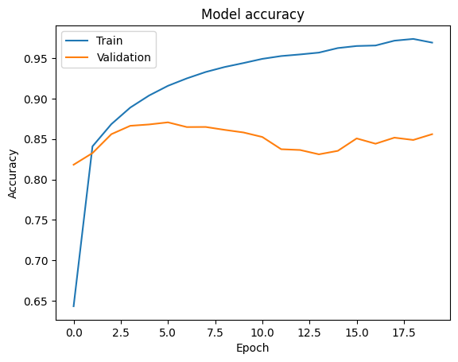

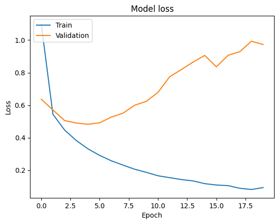

```python
# Plot the training and validation accuracy

plt.plot(cnn_history.history['accuracy'])
plt.plot(cnn_history.history['val_accuracy'])
plt.title('Model accuracy')
plt.ylabel('Accuracy')
plt.xlabel('Epoch')
plt.legend(['Train', 'Validation'], loc='upper left')
plt.show()

# Plot the training and validation loss

plt.plot(cnn_history.history['loss'])
plt.plot(cnn_history.history['val_loss'])
plt.title('Model loss')
plt.ylabel('Loss')
plt.xlabel('Epoch')
plt.legend(['Train', 'Validation'], loc='upper left')
plt.show()
```

**Observations:**

This model is clearly overfitting. We can say that, because after some epochs the accuracy on training data is improving and the accuracy over validation data is clearly going down. Loss function shows us the same result, that the further we go, the worst the model gets. Early stop wouldn't be significative, because it didn't reach a decent accuracy value to think that in earlier epochs the model would do well.

Let's build another model and see if we can get a better model with generalized performance.

First, we need to clear the previous model's history from the Keras backend. Also, let's fix the seed again after clearing the backend.

```python
# Clear Keras backend

keras.backend.clear_session()

# Fix the seed for random number generators

np.random.seed(42)

random.seed(42)

tf.random.set_seed(42)
```

### **Second Model Architecture**

- Write a function that returns a sequential model with the following architecture:
- First Convolutional layer with **16 filters and the kernel size of 3x3**. Use the **'same' padding** and provide the **input shape = (32, 32, 1)**
- Add a **LeakyRelu layer** with the **slope equal to 0.1**
- Second Convolutional layer with **32 filters and the kernel size of 3x3 with 'same' padding**
- Add **LeakyRelu** with the **slope equal to 0.1**
- Add a **max-pooling layer** with a **pool size of 2x2**
- Add a **BatchNormalization layer**
- Third Convolutional layer with **32 filters and the kernel size of 3x3 with 'same' padding**
- Add a **LeakyRelu layer with the slope equal to 0.1**
- Fourth Convolutional layer **64 filters and the kernel size of 3x3 with 'same' padding**
- Add a **LeakyRelu layer with the slope equal to 0.1**
- Add a **max-pooling layer** with a **pool size of 2x2**
- Add a **BatchNormalization layer**
- **Flatten** the output from the previous layer
- Add a **dense layer with 32 nodes**
- Add a **LeakyRelu layer with the slope equal to 0.1**
- Add a **dropout layer with the rate equal to 0.5**
- Add the final **output layer with nodes equal to the number of classes, i.e., 10** and **'softmax' as the activation function**
- Compile the model with the **categorical_crossentropy loss, adam optimizers (learning_rate = 0.001), and metric equal to 'accuracy'**. Do not fit the model here, just return the compiled model.
- Call the function cnn_model_2 and store the model in a new variable.
- Print the summary of the model.
- Fit the model on the train data with a **validation split of 0.2, batch size = 128, verbose = 1, and epochs = 30**. Store the model building history to use later for visualization.

### **Build and train the second CNN model as per the above mentioned architecture.**

```python
def cnn_model_2():

  model = Sequential()

  model.add(Conv2D(filters = 16, kernel_size = (3, 3), padding = 'same', input_shape = (32, 32, 1)))
  model.add(LeakyReLU(negative_slope = 0.1))
  model.add(Conv2D(filters = 32, kernel_size = (3, 3), padding = 'same'))
  model.add(LeakyReLU(negative_slope = 0.1))
  model.add(MaxPool2D(pool_size = (2, 2)))
  model.add(BatchNormalization())
  model.add(Conv2D(filters = 32, kernel_size = (3, 3), padding = 'same'))
  model.add(LeakyReLU(negative_slope = 0.1))
  model.add(Conv2D(filters = 64, kernel_size = (3, 3), padding = 'same'))
  model.add(LeakyReLU(negative_slope = 0.1))
  model.add(MaxPool2D(pool_size = (2, 2)))
  model.add(BatchNormalization())

  model.add(Flatten())

  model.add(Dense(units = 32))
  model.add(LeakyReLU(negative_slope = 0.1))
  model.add(Dropout(0.5))

  model.add(Dense(units = 10, activation = 'softmax'))

  model.compile(loss = 'categorical_crossentropy', optimizer = Adam(learning_rate = 0.001), metrics = ['accuracy'])

  return model
```

```python
cnn_model_2 = cnn_model_2()
cnn_model_2.summary()
```

```
Model: "sequential"
```

```
┏━━━━━━━━━━━━━━━━━━━━━━━━━━━━━━━━━━━━━━┳━━━━━━━━━━━━━━━━━━━━━━━━━━━━━┳━━━━━━━━━━━━━━━━━┓
┃ Layer (type)                         ┃ Output Shape                ┃         Param # ┃
┡━━━━━━━━━━━━━━━━━━━━━━━━━━━━━━━━━━━━━━╇━━━━━━━━━━━━━━━━━━━━━━━━━━━━━╇━━━━━━━━━━━━━━━━━┩
│ conv2d (Conv2D)                      │ (None, 32, 32, 16)          │             160 │
├──────────────────────────────────────┼─────────────────────────────┼─────────────────┤
│ leaky_re_lu (LeakyReLU)              │ (None, 32, 32, 16)          │               0 │
├──────────────────────────────────────┼─────────────────────────────┼─────────────────┤
│ conv2d_1 (Conv2D)                    │ (None, 32, 32, 32)          │           4,640 │
├──────────────────────────────────────┼─────────────────────────────┼─────────────────┤
│ leaky_re_lu_1 (LeakyReLU)            │ (None, 32, 32, 32)          │               0 │
├──────────────────────────────────────┼─────────────────────────────┼─────────────────┤
│ max_pooling2d (MaxPooling2D)         │ (None, 16, 16, 32)          │               0 │
├──────────────────────────────────────┼─────────────────────────────┼─────────────────┤
│ batch_normalization                  │ (None, 16, 16, 32)          │             128 │
│ (BatchNormalization)                 │                             │                 │
├──────────────────────────────────────┼─────────────────────────────┼─────────────────┤
│ conv2d_2 (Conv2D)                    │ (None, 16, 16, 32)          │           9,248 │
├──────────────────────────────────────┼─────────────────────────────┼─────────────────┤
│ leaky_re_lu_2 (LeakyReLU)            │ (None, 16, 16, 32)          │               0 │
├──────────────────────────────────────┼─────────────────────────────┼─────────────────┤
│ conv2d_3 (Conv2D)                    │ (None, 16, 16, 64)          │          18,496 │
├──────────────────────────────────────┼─────────────────────────────┼─────────────────┤
│ leaky_re_lu_3 (LeakyReLU)            │ (None, 16, 16, 64)          │               0 │
├──────────────────────────────────────┼─────────────────────────────┼─────────────────┤
│ max_pooling2d_1 (MaxPooling2D)       │ (None, 8, 8, 64)            │               0 │
├──────────────────────────────────────┼─────────────────────────────┼─────────────────┤
│ batch_normalization_1                │ (None, 8, 8, 64)            │             256 │
│ (BatchNormalization)                 │                             │                 │
├──────────────────────────────────────┼─────────────────────────────┼─────────────────┤
│ flatten (Flatten)                    │ (None, 4096)                │               0 │
├──────────────────────────────────────┼─────────────────────────────┼─────────────────┤
│ dense (Dense)                        │ (None, 32)                  │         131,104 │
├──────────────────────────────────────┼─────────────────────────────┼─────────────────┤
│ leaky_re_lu_4 (LeakyReLU)            │ (None, 32)                  │               0 │
├──────────────────────────────────────┼─────────────────────────────┼─────────────────┤
│ dropout (Dropout)                    │ (None, 32)                  │               0 │
├──────────────────────────────────────┼─────────────────────────────┼─────────────────┤
│ dense_1 (Dense)                      │ (None, 10)                  │             330 │
└──────────────────────────────────────┴─────────────────────────────┴─────────────────┘
```

```
 Total params: 164,362 (642.04 KB)
```

```
 Trainable params: 164,170 (641.29 KB)
```

```
 Non-trainable params: 192 (768.00 B)
```

```python
cnn_history_2 = cnn_model_2.fit(x_train, y_train, validation_split=0.2, batch_size=128, verbose=1, epochs=30)
```

```
263/263 ━━━━━━━━━━━━━━━━━━━━ 9s 18ms/step - accuracy: 0.3345 - loss: 1.9182 - val_accuracy: 0.2651 - val_loss: 1.9251
263/263 ━━━━━━━━━━━━━━━━━━━━ 2s 9ms/step - accuracy: 0.7796 - loss: 0.7180 - val_accuracy: 0.8458 - val_loss: 0.5362
263/263 ━━━━━━━━━━━━━━━━━━━━ 2s 8ms/step - accuracy: 0.8251 - loss: 0.5771 - val_accuracy: 0.8739 - val_loss: 0.4373
263/263 ━━━━━━━━━━━━━━━━━━━━ 2s 7ms/step - accuracy: 0.8475 - loss: 0.4964 - val_accuracy: 0.8858 - val_loss: 0.4165
263/263 ━━━━━━━━━━━━━━━━━━━━ 2s 7ms/step - accuracy: 0.8629 - loss: 0.4461 - val_accuracy: 0.8898 - val_loss: 0.3911
263/263 ━━━━━━━━━━━━━━━━━━━━ 3s 8ms/step - accuracy: 0.8745 - loss: 0.4134 - val_accuracy: 0.8971 - val_loss: 0.3774
263/263 ━━━━━━━━━━━━━━━━━━━━ 3s 8ms/step - accuracy: 0.8826 - loss: 0.3846 - val_accuracy: 0.8925 - val_loss: 0.3846
263/263 ━━━━━━━━━━━━━━━━━━━━ 2s 8ms/step - accuracy: 0.8903 - loss: 0.3545 - val_accuracy: 0.8929 - val_loss: 0.3844
263/263 ━━━━━━━━━━━━━━━━━━━━ 2s 7ms/step - accuracy: 0.8987 - loss: 0.3414 - val_accuracy: 0.8879 - val_loss: 0.3995
263/263 ━━━━━━━━━━━━━━━━━━━━ 2s 8ms/step - accuracy: 0.9018 - loss: 0.3123 - val_accuracy: 0.8968 - val_loss: 0.3898
263/263 ━━━━━━━━━━━━━━━━━━━━ 2s 8ms/step - accuracy: 0.9032 - loss: 0.3060 - val_accuracy: 0.9087 - val_loss: 0.3534
263/263 ━━━━━━━━━━━━━━━━━━━━ 2s 7ms/step - accuracy: 0.9089 - loss: 0.2939 - val_accuracy: 0.8920 - val_loss: 0.3968
263/263 ━━━━━━━━━━━━━━━━━━━━ 3s 8ms/step - accuracy: 0.9123 - loss: 0.2768 - val_accuracy: 0.8835 - val_loss: 0.4266
263/263 ━━━━━━━━━━━━━━━━━━━━ 2s 8ms/step - accuracy: 0.9148 - loss: 0.2658 - val_accuracy: 0.9058 - val_loss: 0.3828
263/263 ━━━━━━━━━━━━━━━━━━━━ 2s 7ms/step - accuracy: 0.9224 - loss: 0.2423 - val_accuracy: 0.9094 - val_loss: 0.3728
263/263 ━━━━━━━━━━━━━━━━━━━━ 2s 8ms/step - accuracy: 0.9249 - loss: 0.2451 - val_accuracy: 0.9089 - val_loss: 0.3752
263/263 ━━━━━━━━━━━━━━━━━━━━ 2s 7ms/step - accuracy: 0.9260 - loss: 0.2289 - val_accuracy: 0.9082 - val_loss: 0.3740
263/263 ━━━━━━━━━━━━━━━━━━━━ 2s 8ms/step - accuracy: 0.9294 - loss: 0.2199 - val_accuracy: 0.8956 - val_loss: 0.4132
263/263 ━━━━━━━━━━━━━━━━━━━━ 3s 8ms/step - accuracy: 0.9277 - loss: 0.2204 - val_accuracy: 0.8614 - val_loss: 0.5767
263/263 ━━━━━━━━━━━━━━━━━━━━ 2s 8ms/step - accuracy: 0.9333 - loss: 0.2053 - val_accuracy: 0.8937 - val_loss: 0.4452
263/263 ━━━━━━━━━━━━━━━━━━━━ 2s 7ms/step - accuracy: 0.9366 - loss: 0.1987 - val_accuracy: 0.8933 - val_loss: 0.4952
263/263 ━━━━━━━━━━━━━━━━━━━━ 2s 7ms/step - accuracy: 0.9365 - loss: 0.1886 - val_accuracy: 0.8838 - val_loss: 0.4780
263/263 ━━━━━━━━━━━━━━━━━━━━ 3s 8ms/step - accuracy: 0.9394 - loss: 0.1830 - val_accuracy: 0.8930 - val_loss: 0.4644
263/263 ━━━━━━━━━━━━━━━━━━━━ 2s 7ms/step - accuracy: 0.9402 - loss: 0.1825 - val_accuracy: 0.8865 - val_loss: 0.4763
263/263 ━━━━━━━━━━━━━━━━━━━━ 3s 8ms/step - accuracy: 0.9414 - loss: 0.1746 - val_accuracy: 0.9021 - val_loss: 0.4542
263/263 ━━━━━━━━━━━━━━━━━━━━ 2s 8ms/step - accuracy: 0.9405 - loss: 0.1789 - val_accuracy: 0.9013 - val_loss: 0.4722
263/263 ━━━━━━━━━━━━━━━━━━━━ 2s 7ms/step - accuracy: 0.9459 - loss: 0.1649 - val_accuracy: 0.9100 - val_loss: 0.4478
263/263 ━━━━━━━━━━━━━━━━━━━━ 3s 7ms/step - accuracy: 0.9444 - loss: 0.1656 - val_accuracy: 0.9036 - val_loss: 0.5504
263/263 ━━━━━━━━━━━━━━━━━━━━ 3s 8ms/step - accuracy: 0.9490 - loss: 0.1559 - val_accuracy: 0.9120 - val_loss: 0.4384
263/263 ━━━━━━━━━━━━━━━━━━━━ 2s 7ms/step - accuracy: 0.9520 - loss: 0.1470 - val_accuracy: 0.9112 - val_loss: 0.4802
```

### **Plot the Training and Validation accuracies and write your observations.**

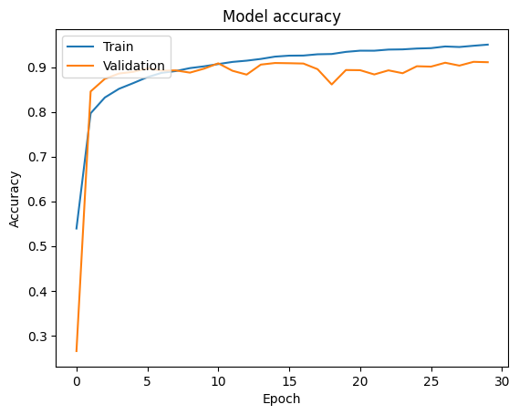

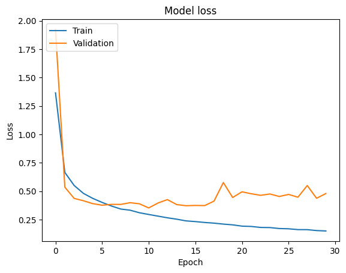

```python
# Plot the training and validation accuracy

plt.plot(cnn_history_2.history['accuracy'])
plt.plot(cnn_history_2.history['val_accuracy'])
plt.title('Model accuracy')
plt.ylabel('Accuracy')
plt.xlabel('Epoch')
plt.legend(['Train', 'Validation'], loc='upper left')
plt.show()

# Plot the training and validation loss

plt.plot(cnn_history_2.history['loss'])
plt.plot(cnn_history_2.history['val_loss'])
plt.title('Model loss')
plt.ylabel('Loss')
plt.xlabel('Epoch')
plt.legend(['Train', 'Validation'], loc='upper left')
plt.show()
```

**Observations:**

We see some noise and a gap betwee the training and validation data, something that could be result of some kind of overfitting, but even with that the accuracy on both datas looks better than above models. Early stop could improve the model, but testing it with our test data would show us how well or badly is it doing.

## **Predictions on the test data**

- Make predictions on the test set using the second model.
- Print the obtained results using the classification report and the confusion matrix.
- Final observations on the obtained results.

### **Make predictions on the test data using the second model.**

```python
test_pred = cnn_model_2.predict(x_test)
test_pred = np.argmax(test_pred, axis=1)
print(test_pred)
```

```
563/563 ━━━━━━━━━━━━━━━━━━━━ 2s 3ms/step
[1 7 2 ... 7 3 2]
```

**Note:** Earlier, we noticed that each entry of the target variable is a one-hot encoded vector, but to print the classification report and confusion matrix, we must convert each entry of y_test to a single label.

```python
y_test = np.argmax(y_test, axis=1)
print(y_test)
```

```
[1 7 2 ... 7 9 2]
```

```
              precision    recall  f1-score   support

           0       0.93      0.93      0.93      1814
           1       0.87      0.93      0.90      1828
           2       0.91      0.94      0.92      1803
           3       0.87      0.90      0.88      1719
           4       0.93      0.92      0.93      1812
           5       0.89      0.92      0.90      1768
           6       0.92      0.88      0.90      1832
           7       0.96      0.90      0.93      1808
           8       0.90      0.90      0.90      1812
           9       0.95      0.88      0.91      1804

    accuracy                           0.91     18000
   macro avg       0.91      0.91      0.91     18000
weighted avg       0.91      0.91      0.91     18000
```

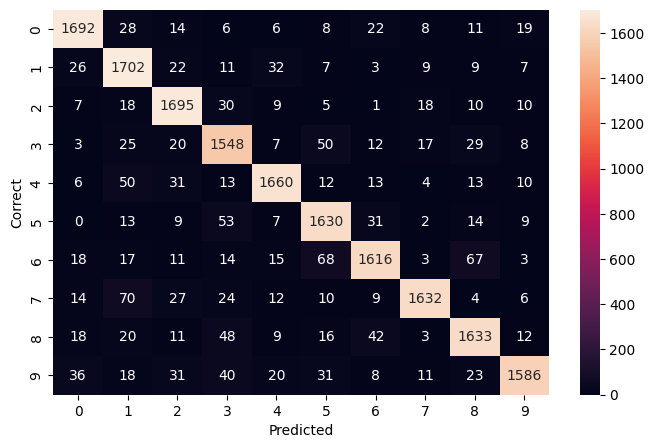

```python
print(classification_report(y_test, test_pred))

# Plotting the heatmap using confusion matrix

cm = confusion_matrix(y_test, test_pred)
plt.figure(figsize = (8, 5))

sns.heatmap(cm, annot = True,  fmt = '.0f')

plt.ylabel('Correct')

plt.xlabel('Predicted')

plt.show()
```

### **Write your final observations on the performance of the model on the test data.**

**Final Observations:**

- The final CNN model shows a significant improvement in accuracy compared to the previous models.
- The training and validation accuracy curves indicate that the model is learning effectively, although there is some noise and a gap between the training and validation accuracy, suggesting slight overfitting.
- The classification report and confusion matrix show that the model performs well on the test data, with high precision, recall, and F1-scores for most classes.
- The addition of more convolutional layers, batch normalization, and dropout layers helped in improving the model's performance and generalization, something that the previous model wasn't doing well.
- Final CNN model can get better with an early stop.
- Overall, the final CNN model demonstrates good learning and generalization capabilities, making it a suitable choice for the digit recognition task.

We can see how the CNN model with 164,362 parameters versus the 310,250 parameters of the second ANN model is much more effective because of the convolutional techniques helping to improve the overall perfomr of the model.

Even with this improvement on the model accuracy, reaching 91%, in my opinion, shouldn't be enough for a good model.

Last model could improve with some hyperparameters tunning or just creating a new model.

We can clearly see how CNN does much better on matrix data structures than ANN, because of the capabilities of aplyinng filters to extract more information about locality, color/intensity depending on the image and other features.

**Last attempt of a model:**

The last model was for now the best model, but I want to try one by my own before taking any last decision about how I good the model I'm presenting is.

Restart everything, clear backend and re seed the features.

```python
# Clear Keras backend

keras.backend.clear_session()

# Fix the seed for random number generators

np.random.seed(42)

random.seed(42)

tf.random.set_seed(42)
```

Load the data to train the new model.

```python
# Load the data
data_file = h5py.File('/content/drive/MyDrive/Digit Recognition Elective Project/SVHN_single_grey1.h5')

# Split the data
x_train = data_file['X_train'][:]
y_train = data_file['y_train'][:]
x_test = data_file['X_test'][:]
y_test = data_file['y_test'][:]

# Close the file
data_file.close()
```

We already now the data structure from earlier analysis, so I'm gonna continue with the normalization and reshaping.

```python
# Reshaping dataset

x_train = x_train.reshape(x_train.shape[0], 32, 32, 1)
x_test = x_test.reshape(x_test.shape[0], 32, 32, 1)
```

```python
# Normalization

x_train = x_train / 255.0
x_test = x_test / 255.0
```

```python
# One-Hot encode

y_test = to_categorical(y_test, num_classes=10)
y_train = to_categorical(y_train, num_classes=10)
```

```python
def cnn_model_3():

  model = Sequential()

  # Same CNN from last model

  model.add(Conv2D(filters = 16, kernel_size = (3, 3), padding = 'same', input_shape = (32, 32, 1)))
  model.add(LeakyReLU(negative_slope = 0.1))
  model.add(Conv2D(filters = 32, kernel_size = (3, 3), padding = 'same'))
  model.add(LeakyReLU(negative_slope = 0.1))
  model.add(MaxPool2D(pool_size = (2, 2)))
  model.add(BatchNormalization())
  model.add(Conv2D(filters = 32, kernel_size = (3, 3), padding = 'same'))
  model.add(LeakyReLU(negative_slope = 0.1))
  model.add(Conv2D(filters = 64, kernel_size = (3, 3), padding = 'same'))
  model.add(LeakyReLU(negative_slope = 0.1))
  model.add(MaxPool2D(pool_size = (2, 2)))
  model.add(BatchNormalization())

  model.add(Flatten())

  # I've added some dense layers for a more accurate model and droput layers

  model.add(Dense(units = 64))
  model.add(LeakyReLU(negative_slope = 0.1))
  model.add(Dropout(0.5))
  model.add(Dense(units = 64))
  model.add(LeakyReLU(negative_slope = 0.1))
  model.add(Dropout(0.5))
  model.add(Dense(units = 32))
  model.add(LeakyReLU(negative_slope = 0.1))
  model.add(Dropout(0.5))

  model.add(Dense(units = 10, activation = 'softmax'))

  model.compile(loss = 'categorical_crossentropy', optimizer = Adam(learning_rate = 0.001), metrics = ['accuracy'])

  return model
```

```python
cnn_model_3 = cnn_model_3()
cnn_model_3.summary()
```

```
Model: "sequential_1"
```

```
┏━━━━━━━━━━━━━━━━━━━━━━━━━━━━━━━━━━━━━━┳━━━━━━━━━━━━━━━━━━━━━━━━━━━━━┳━━━━━━━━━━━━━━━━━┓
┃ Layer (type)                         ┃ Output Shape                ┃         Param # ┃
┡━━━━━━━━━━━━━━━━━━━━━━━━━━━━━━━━━━━━━━╇━━━━━━━━━━━━━━━━━━━━━━━━━━━━━╇━━━━━━━━━━━━━━━━━┩
│ conv2d_4 (Conv2D)                    │ (None, 32, 32, 16)          │             160 │
├──────────────────────────────────────┼─────────────────────────────┼─────────────────┤
│ leaky_re_lu_7 (LeakyReLU)            │ (None, 32, 32, 16)          │               0 │
├──────────────────────────────────────┼─────────────────────────────┼─────────────────┤
│ conv2d_5 (Conv2D)                    │ (None, 32, 32, 32)          │           4,640 │
├──────────────────────────────────────┼─────────────────────────────┼─────────────────┤
│ leaky_re_lu_8 (LeakyReLU)            │ (None, 32, 32, 32)          │               0 │
├──────────────────────────────────────┼─────────────────────────────┼─────────────────┤
│ max_pooling2d_2 (MaxPooling2D)       │ (None, 16, 16, 32)          │               0 │
├──────────────────────────────────────┼─────────────────────────────┼─────────────────┤
│ batch_normalization_2                │ (None, 16, 16, 32)          │             128 │
│ (BatchNormalization)                 │                             │                 │
├──────────────────────────────────────┼─────────────────────────────┼─────────────────┤
│ conv2d_6 (Conv2D)                    │ (None, 16, 16, 32)          │           9,248 │
├──────────────────────────────────────┼─────────────────────────────┼─────────────────┤
│ leaky_re_lu_9 (LeakyReLU)            │ (None, 16, 16, 32)          │               0 │
├──────────────────────────────────────┼─────────────────────────────┼─────────────────┤
│ conv2d_7 (Conv2D)                    │ (None, 16, 16, 64)          │          18,496 │
├──────────────────────────────────────┼─────────────────────────────┼─────────────────┤
│ leaky_re_lu_10 (LeakyReLU)           │ (None, 16, 16, 64)          │               0 │
├──────────────────────────────────────┼─────────────────────────────┼─────────────────┤
│ max_pooling2d_3 (MaxPooling2D)       │ (None, 8, 8, 64)            │               0 │
├──────────────────────────────────────┼─────────────────────────────┼─────────────────┤
│ batch_normalization_3                │ (None, 8, 8, 64)            │             256 │
│ (BatchNormalization)                 │                             │                 │
├──────────────────────────────────────┼─────────────────────────────┼─────────────────┤
│ flatten_1 (Flatten)                  │ (None, 4096)                │               0 │
├──────────────────────────────────────┼─────────────────────────────┼─────────────────┤
│ dense_4 (Dense)                      │ (None, 64)                  │         262,208 │
├──────────────────────────────────────┼─────────────────────────────┼─────────────────┤
│ leaky_re_lu_11 (LeakyReLU)           │ (None, 64)                  │               0 │
├──────────────────────────────────────┼─────────────────────────────┼─────────────────┤
│ dropout_3 (Dropout)                  │ (None, 64)                  │               0 │
├──────────────────────────────────────┼─────────────────────────────┼─────────────────┤
│ dense_5 (Dense)                      │ (None, 64)                  │           4,160 │
├──────────────────────────────────────┼─────────────────────────────┼─────────────────┤
│ leaky_re_lu_12 (LeakyReLU)           │ (None, 64)                  │               0 │
├──────────────────────────────────────┼─────────────────────────────┼─────────────────┤
│ dropout_4 (Dropout)                  │ (None, 64)                  │               0 │
├──────────────────────────────────────┼─────────────────────────────┼─────────────────┤
│ dense_6 (Dense)                      │ (None, 32)                  │           2,080 │
├──────────────────────────────────────┼─────────────────────────────┼─────────────────┤
│ leaky_re_lu_13 (LeakyReLU)           │ (None, 32)                  │               0 │
├──────────────────────────────────────┼─────────────────────────────┼─────────────────┤
│ dropout_5 (Dropout)                  │ (None, 32)                  │               0 │
├──────────────────────────────────────┼─────────────────────────────┼─────────────────┤
│ dense_7 (Dense)                      │ (None, 10)                  │             330 │
└──────────────────────────────────────┴─────────────────────────────┴─────────────────┘
```

```
 Total params: 301,706 (1.15 MB)
```

```
 Trainable params: 301,514 (1.15 MB)
```

```
 Non-trainable params: 192 (768.00 B)
```

```python
# Fittin the model to use it for predictions

cnn_history_3 = cnn_model_3.fit(x_train, y_train, validation_split=0.2, batch_size=128, verbose=1, epochs=30)
```

```
263/263 ━━━━━━━━━━━━━━━━━━━━ 12s 22ms/step - accuracy: 0.1045 - loss: 2.4600 - val_accuracy: 0.0969 - val_loss: 3.2012
263/263 ━━━━━━━━━━━━━━━━━━━━ 2s 8ms/step - accuracy: 0.2436 - loss: 2.0566 - val_accuracy: 0.6086 - val_loss: 1.1321
263/263 ━━━━━━━━━━━━━━━━━━━━ 2s 8ms/step - accuracy: 0.6142 - loss: 1.1580 - val_accuracy: 0.8124 - val_loss: 0.6478
263/263 ━━━━━━━━━━━━━━━━━━━━ 2s 7ms/step - accuracy: 0.7272 - loss: 0.8696 - val_accuracy: 0.8521 - val_loss: 0.5422
263/263 ━━━━━━━━━━━━━━━━━━━━ 2s 7ms/step - accuracy: 0.7908 - loss: 0.7106 - val_accuracy: 0.8575 - val_loss: 0.5250
263/263 ━━━━━━━━━━━━━━━━━━━━ 2s 7ms/step - accuracy: 0.8159 - loss: 0.6345 - val_accuracy: 0.8536 - val_loss: 0.5297
263/263 ━━━━━━━━━━━━━━━━━━━━ 2s 8ms/step - accuracy: 0.8391 - loss: 0.5731 - val_accuracy: 0.8773 - val_loss: 0.4427
263/263 ━━━━━━━━━━━━━━━━━━━━ 2s 8ms/step - accuracy: 0.8500 - loss: 0.5140 - val_accuracy: 0.8895 - val_loss: 0.4027
263/263 ━━━━━━━━━━━━━━━━━━━━ 3s 9ms/step - accuracy: 0.8606 - loss: 0.4952 - val_accuracy: 0.8867 - val_loss: 0.4069
263/263 ━━━━━━━━━━━━━━━━━━━━ 2s 7ms/step - accuracy: 0.8752 - loss: 0.4445 - val_accuracy: 0.8851 - val_loss: 0.4312
263/263 ━━━━━━━━━━━━━━━━━━━━ 2s 7ms/step - accuracy: 0.8801 - loss: 0.4281 - val_accuracy: 0.8908 - val_loss: 0.4236
263/263 ━━━━━━━━━━━━━━━━━━━━ 2s 8ms/step - accuracy: 0.8844 - loss: 0.4157 - val_accuracy: 0.8998 - val_loss: 0.3871
263/263 ━━━━━━━━━━━━━━━━━━━━ 2s 8ms/step - accuracy: 0.8945 - loss: 0.3728 - val_accuracy: 0.8940 - val_loss: 0.3962
263/263 ━━━━━━━━━━━━━━━━━━━━ 3s 8ms/step - accuracy: 0.8964 - loss: 0.3721 - val_accuracy: 0.9035 - val_loss: 0.3845
263/263 ━━━━━━━━━━━━━━━━━━━━ 2s 9ms/step - accuracy: 0.9026 - loss: 0.3507 - val_accuracy: 0.8990 - val_loss: 0.3886
263/263 ━━━━━━━━━━━━━━━━━━━━ 2s 8ms/step - accuracy: 0.9093 - loss: 0.3236 - val_accuracy: 0.9094 - val_loss: 0.3843
263/263 ━━━━━━━━━━━━━━━━━━━━ 3s 8ms/step - accuracy: 0.9090 - loss: 0.3249 - val_accuracy: 0.8806 - val_loss: 0.4482
263/263 ━━━━━━━━━━━━━━━━━━━━ 2s 8ms/step - accuracy: 0.9152 - loss: 0.3042 - val_accuracy: 0.8971 - val_loss: 0.4326
263/263 ━━━━━━━━━━━━━━━━━━━━ 2s 8ms/step - accuracy: 0.9170 - loss: 0.2927 - val_accuracy: 0.9046 - val_loss: 0.4319
263/263 ━━━━━━━━━━━━━━━━━━━━ 2s 9ms/step - accuracy: 0.9222 - loss: 0.2743 - val_accuracy: 0.9019 - val_loss: 0.4379
263/263 ━━━━━━━━━━━━━━━━━━━━ 2s 9ms/step - accuracy: 0.9267 - loss: 0.2626 - val_accuracy: 0.9038 - val_loss: 0.4337
263/263 ━━━━━━━━━━━━━━━━━━━━ 2s 9ms/step - accuracy: 0.9285 - loss: 0.2545 - val_accuracy: 0.9056 - val_loss: 0.3896
263/263 ━━━━━━━━━━━━━━━━━━━━ 2s 9ms/step - accuracy: 0.9276 - loss: 0.2515 - val_accuracy: 0.9033 - val_loss: 0.4186
263/263 ━━━━━━━━━━━━━━━━━━━━ 3s 10ms/step - accuracy: 0.9275 - loss: 0.2511 - val_accuracy: 0.9062 - val_loss: 0.4237
263/263 ━━━━━━━━━━━━━━━━━━━━ 3s 10ms/step - accuracy: 0.9328 - loss: 0.2395 - val_accuracy: 0.9077 - val_loss: 0.4319
263/263 ━━━━━━━━━━━━━━━━━━━━ 2s 9ms/step - accuracy: 0.9310 - loss: 0.2370 - val_accuracy: 0.9062 - val_loss: 0.4513
263/263 ━━━━━━━━━━━━━━━━━━━━ 2s 8ms/step - accuracy: 0.9372 - loss: 0.2103 - val_accuracy: 0.9045 - val_loss: 0.4834
263/263 ━━━━━━━━━━━━━━━━━━━━ 2s 8ms/step - accuracy: 0.9392 - loss: 0.2161 - val_accuracy: 0.9069 - val_loss: 0.4448
263/263 ━━━━━━━━━━━━━━━━━━━━ 2s 8ms/step - accuracy: 0.9346 - loss: 0.2195 - val_accuracy: 0.9106 - val_loss: 0.4403
263/263 ━━━━━━━━━━━━━━━━━━━━ 3s 10ms/step - accuracy: 0.9374 - loss: 0.2131 - val_accuracy: 0.9086 - val_loss: 0.4245
```

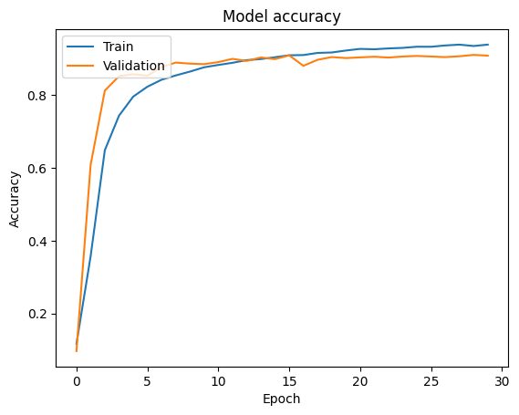

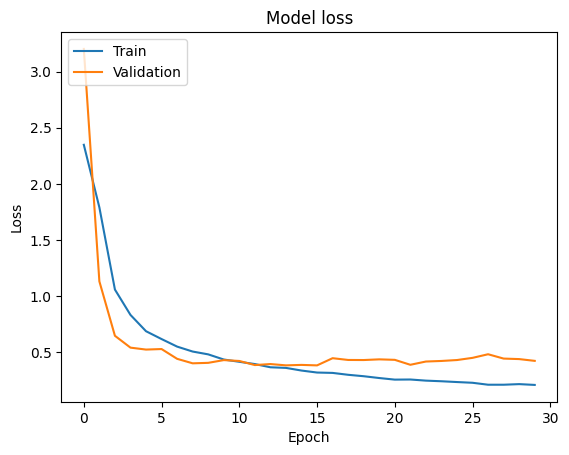

```python
# Plot the training and validation accuracy

plt.plot(cnn_history_3.history['accuracy'])
plt.plot(cnn_history_3.history['val_accuracy'])
plt.title('Model accuracy')
plt.ylabel('Accuracy')
plt.xlabel('Epoch')
plt.legend(['Train', 'Validation'], loc='upper left')
plt.show()

# Plot the training and validation loss

plt.plot(cnn_history_3.history['loss'])
plt.plot(cnn_history_3.history['val_loss'])
plt.title('Model loss')
plt.ylabel('Loss')
plt.xlabel('Epoch')
plt.legend(['Train', 'Validation'], loc='upper left')
plt.show()
```

```python
# Making prediction on test data

test_pred_3 = cnn_model_3.predict(x_test)
test_pred_3 = np.argmax(test_pred_3, axis=1)
print(test_pred)
```

[output not shown]

```python
# Decoding the test labels

y_test = np.argmax(y_test, axis=1)
print(y_test)
```

```
[1 7 2 ... 7 9 2]
```

```
              precision    recall  f1-score   support

           0       0.92      0.95      0.94      1814
           1       0.88      0.93      0.90      1828
           2       0.95      0.92      0.93      1803
           3       0.86      0.89      0.87      1719
           4       0.95      0.91      0.93      1812
           5       0.89      0.92      0.91      1768
           6       0.89      0.90      0.90      1832
           7       0.96      0.90      0.93      1808
           8       0.88      0.89      0.88      1812
           9       0.92      0.89      0.91      1804

    accuracy                           0.91     18000
   macro avg       0.91      0.91      0.91     18000
weighted avg       0.91      0.91      0.91     18000
```

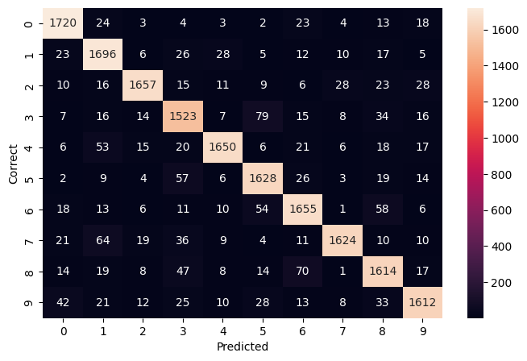

```python
print(classification_report(y_test, test_pred_3))

# Plotting the heatmap using confusion matrix

cm = confusion_matrix(y_test, test_pred_3)
plt.figure(figsize = (8, 5))

sns.heatmap(cm, annot = True,  fmt = '.0f')

plt.ylabel('Correct')

plt.xlabel('Predicted')

plt.show()
```

As we can see here a more complex model is not doing much better than the previous model.

We have less overfitting since the gap between train and validation acuraccy is lower than on the previous model, but with almost twice the parameters the previous model.

I will keep the results of CNN model 2, because it is not gonna be that complex, easier to train with less trainable parameters and simpler structer (less layers).

We didn't get anything significant with a more complex model.